# Analyse Multivariée — Wine Quality (UCI)

Wala Mhatli

Omar Ghannem

Oumaima Ghannem

2026-05-17

# 1 Introduction

Ce rapport présente une analyse multivariée du dataset **Wine Quality (UCI)** portant sur les vins rouges. L’objectif est d’explorer les relations entre les caractéristiques physicochimiques des vins, de réduire la dimensionnalité via une ACP, puis d’identifier des groupes de vins homogènes par classification.

# 2 Chargement des packages

```r
library(tidyverse)
library(FactoMineR)
library(factoextra)
library(cluster)
library(corrplot)
library(gridExtra)
```

# 3 Chargement des données

```r
url  <- "https://archive.ics.uci.edu/ml/machine-learning-databases/wine-quality/winequality-red.csv"
wine <- read.csv(url, sep = ";")

dim(wine)
```

```
## [1] 1599   12
```

```r
head(wine)
```

```
##   fixed.acidity volatile.acidity citric.acid residual.sugar chlorides
## 1           7.4             0.70        0.00            1.9     0.076
## 2           7.8             0.88        0.00            2.6     0.098
## 3           7.8             0.76        0.04            2.3     0.092
## 4          11.2             0.28        0.56            1.9     0.075
## 5           7.4             0.70        0.00            1.9     0.076
## 6           7.4             0.66        0.00            1.8     0.075
##   free.sulfur.dioxide total.sulfur.dioxide density   pH sulphates alcohol
## 1                  11                   34  0.9978 3.51      0.56     9.4
## 2                  25                   67  0.9968 3.20      0.68     9.8
## 3                  15                   54  0.9970 3.26      0.65     9.8
## 4                  17                   60  0.9980 3.16      0.58     9.8
## 5                  11                   34  0.9978 3.51      0.56     9.4
## 6                  13                   40  0.9978 3.51      0.56     9.4
##   quality
## 1       5
## 2       5
## 3       5
## 4       6
## 5       5
## 6       5
```

```r
str(wine)
```

```
## 'data.frame':    1599 obs. of  12 variables:
##  $ fixed.acidity       : num  7.4 7.8 7.8 11.2 7.4 7.4 7.9 7.3 7.8 7.5 ...
##  $ volatile.acidity    : num  0.7 0.88 0.76 0.28 0.7 0.66 0.6 0.65 0.58 0.5 ...
##  $ citric.acid         : num  0 0 0.04 0.56 0 0 0.06 0 0.02 0.36 ...
##  $ residual.sugar      : num  1.9 2.6 2.3 1.9 1.9 1.8 1.6 1.2 2 6.1 ...
##  $ chlorides           : num  0.076 0.098 0.092 0.075 0.076 0.075 0.069 0.065 0.073 0.071 ...
##  $ free.sulfur.dioxide : num  11 25 15 17 11 13 15 15 9 17 ...
##  $ total.sulfur.dioxide: num  34 67 54 60 34 40 59 21 18 102 ...
##  $ density             : num  0.998 0.997 0.997 0.998 0.998 ...
##  $ pH                  : num  3.51 3.2 3.26 3.16 3.51 3.51 3.3 3.39 3.36 3.35 ...
##  $ sulphates           : num  0.56 0.68 0.65 0.58 0.56 0.56 0.46 0.47 0.57 0.8 ...
##  $ alcohol             : num  9.4 9.8 9.8 9.8 9.4 9.4 9.4 10 9.5 10.5 ...
##  $ quality             : int  5 5 5 6 5 5 5 7 7 5 ...
```

```r
summary(wine)
```

```
##  fixed.acidity   volatile.acidity  citric.acid    residual.sugar
##  Min.   : 4.60   Min.   :0.1200   Min.   :0.000   Min.   : 0.900
##  1st Qu.: 7.10   1st Qu.:0.3900   1st Qu.:0.090   1st Qu.: 1.900
##  Median : 7.90   Median :0.5200   Median :0.260   Median : 2.200
##  Mean   : 8.32   Mean   :0.5278   Mean   :0.271   Mean   : 2.539
##  3rd Qu.: 9.20   3rd Qu.:0.6400   3rd Qu.:0.420   3rd Qu.: 2.600
##  Max.   :15.90   Max.   :1.5800   Max.   :1.000   Max.   :15.500
##    chlorides       free.sulfur.dioxide total.sulfur.dioxide    density
##  Min.   :0.01200   Min.   : 1.00       Min.   :  6.00       Min.   :0.9901
##  1st Qu.:0.07000   1st Qu.: 7.00       1st Qu.: 22.00       1st Qu.:0.9956
##  Median :0.07900   Median :14.00       Median : 38.00       Median :0.9968
##  Mean   :0.08747   Mean   :15.87       Mean   : 46.47       Mean   :0.9967
##  3rd Qu.:0.09000   3rd Qu.:21.00       3rd Qu.: 62.00       3rd Qu.:0.9978
##  Max.   :0.61100   Max.   :72.00       Max.   :289.00       Max.   :1.0037
##        pH          sulphates         alcohol         quality
##  Min.   :2.740   Min.   :0.3300   Min.   : 8.40   Min.   :3.000
##  1st Qu.:3.210   1st Qu.:0.5500   1st Qu.: 9.50   1st Qu.:5.000
##  Median :3.310   Median :0.6200   Median :10.20   Median :6.000
##  Mean   :3.311   Mean   :0.6581   Mean   :10.42   Mean   :5.636
##  3rd Qu.:3.400   3rd Qu.:0.7300   3rd Qu.:11.10   3rd Qu.:6.000
##  Max.   :4.010   Max.   :2.0000   Max.   :14.90   Max.   :8.000
```

Le dataset contient **1599 observations** et **12 variables**, dont 11 variables physicochimiques et une variable cible `quality`.

# 4 Préparation et nettoyage des données

## 4.1 Valeurs manquantes

```r
colSums(is.na(wine))
```

```
##        fixed.acidity     volatile.acidity          citric.acid
##                    0                    0                    0
##       residual.sugar            chlorides  free.sulfur.dioxide
##                    0                    0                    0
## total.sulfur.dioxide              density                   pH
##                    0                    0                    0
##            sulphates              alcohol              quality
##                    0                    0                    0
```

Aucune valeur manquante n’est détectée dans le dataset.

## 4.2 Doublons

```r
nb_doublons <- sum(duplicated(wine))
cat("Nombre de doublons :", nb_doublons, "\n")
```

```
## Nombre de doublons : 240
```

```r
wine_clean <- wine[!duplicated(wine), ]
cat("Dimensions après nettoyage :", nrow(wine_clean), "x", ncol(wine_clean), "\n")
```

```
## Dimensions après nettoyage : 1359 x 12
```

## 4.3 Séparation variables actives / variable cible

```r
wine_vars    <- wine_clean[, 1:11]
wine_quality <- wine_clean$quality
```

## 4.4 Détection des outliers

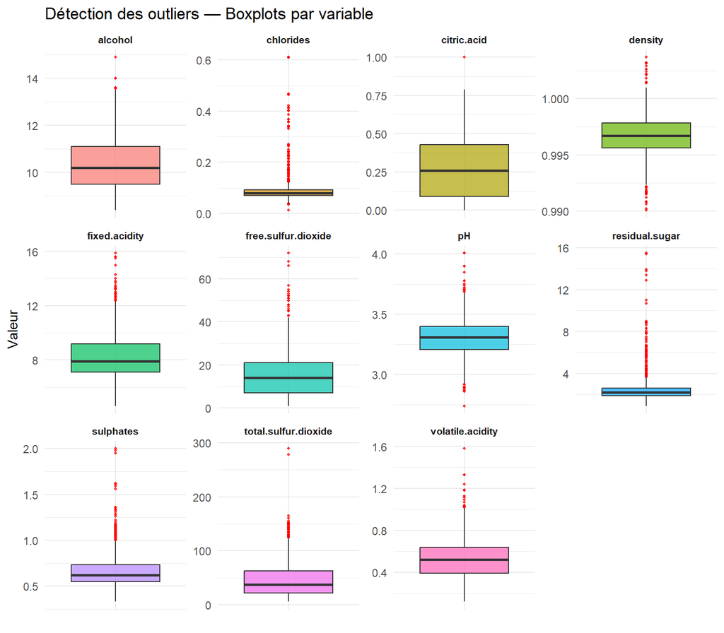

```r
wine_long <- wine_vars %>%
  pivot_longer(cols = everything(),
               names_to  = "variable",
               values_to = "valeur")

ggplot(wine_long, aes(x = variable, y = valeur, fill = variable)) +
  geom_boxplot(outlier.colour = "red", outlier.size = 0.8, alpha = 0.7) +
  facet_wrap(~variable, scales = "free", ncol = 4) +
  theme_minimal() +
  theme(legend.position = "none",
        axis.text.x     = element_blank(),
        strip.text      = element_text(size = 8, face = "bold")) +
  labs(title = "Détection des outliers — Boxplots par variable",
       x = "", y = "Valeur")
```

> **Observation :** `residual.sugar`, `total.sulfur.dioxide` et `chlorides` présentent des outliers marqués. Ils sont conservés car ils représentent des profils de vins réels et atypiques.

## 4.5 Normalisation (Z-score)

```r
wine_scaled <- scale(wine_vars)

round(colMeans(wine_scaled), 3)
```

```
##        fixed.acidity     volatile.acidity          citric.acid
##                    0                    0                    0
##       residual.sugar            chlorides  free.sulfur.dioxide
##                    0                    0                    0
## total.sulfur.dioxide              density                   pH
##                    0                    0                    0
##            sulphates              alcohol
##                    0                    0
```

```r
round(apply(wine_scaled, 2, sd), 3)
```

```
##        fixed.acidity     volatile.acidity          citric.acid
##                    1                    1                    1
##       residual.sugar            chlorides  free.sulfur.dioxide
##                    1                    1                    1
## total.sulfur.dioxide              density                   pH
##                    1                    1                    1
##            sulphates              alcohol
##                    1                    1
```

## 4.6 Matrice de corrélation

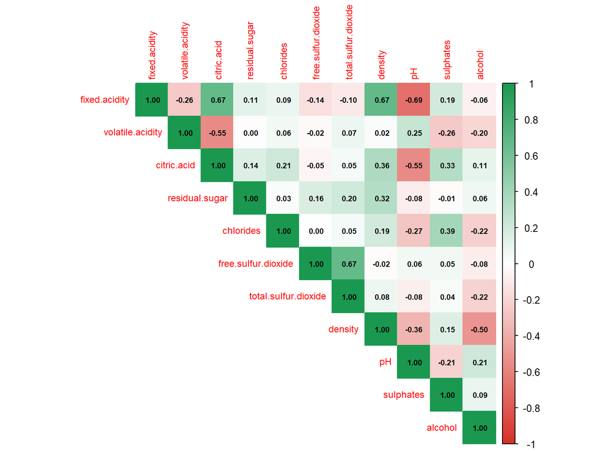

```r
corrplot(cor(wine_vars),
         method      = "color",
         type        = "upper",
         tl.cex      = 0.75,
         addCoef.col = "black",
         number.cex  = 0.6,
         col         = colorRampPalette(c("#d73027","white","#1a9850"))(200),
         mar         = c(0, 0, 0, 0))
```

> Des corrélations fortes sont observées : `fixed.acidity` / `citric.acid` (+0.67) et `fixed.acidity` / `pH` (−0.69). Ces redondances justifient le recours à l’ACP.

# 5 Analyse en Composantes Principales (ACP)

## 5.1 Réalisation de l’ACP

```r
acp <- PCA(wine_vars,
           scale.unit = TRUE,
           ncp        = 5,
           graph      = FALSE)
```

## 5.2 Scree Plot — Variance expliquée

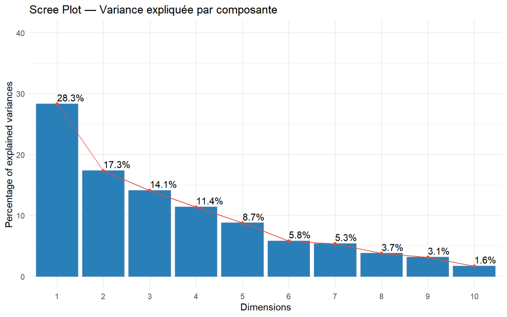

```r
fviz_eig(acp,
         addlabels = TRUE,
         ylim      = c(0, 40),
         barfill   = "#2980B9",
         linecolor = "#E74C3C") +
  labs(title = "Scree Plot — Variance expliquée par composante") +
  theme_minimal()
```

```r
print(round(acp$eig, 2))
```

```
##         eigenvalue percentage of variance cumulative percentage of variance
## comp 1        3.11                  28.29                             28.29
## comp 2        1.91                  17.35                             45.64
## comp 3        1.55                  14.07                             59.71
## comp 4        1.25                  11.37                             71.08
## comp 5        0.96                   8.74                             79.81
## comp 6        0.64                   5.80                             85.61
## comp 7        0.59                   5.34                             90.94
## comp 8        0.41                   3.75                             94.69
## comp 9        0.34                   3.13                             97.82
## comp 10       0.18                   1.65                             99.46
## comp 11       0.06                   0.54                            100.00
```

> **Décision :** 4 composantes retenues (règle de Kaiser + coude) → **71.1% de variance expliquée**.

## 5.3 Contributions des variables

```r
print(round(acp$var$contrib[, 1:4], 2))
```

```
##                      Dim.1 Dim.2 Dim.3 Dim.4
## fixed.acidity        23.55  1.24  1.65  5.55
## volatile.acidity      5.73  7.64 19.70  0.53
## citric.acid          21.39  2.41  5.60  0.56
## residual.sugar        1.81  5.66  1.31 16.42
## chlorides             4.59  1.71  0.85 42.75
## free.sulfur.dioxide   0.05 26.26 19.08  0.05
## total.sulfur.dioxide  0.13 33.22 10.71  0.08
## density              15.35  5.32 12.23  3.23
## pH                   19.74  0.00  0.30  0.00
## sulphates             6.27  0.30  6.91 29.19
## alcohol               1.39 16.24 21.65  1.64
```

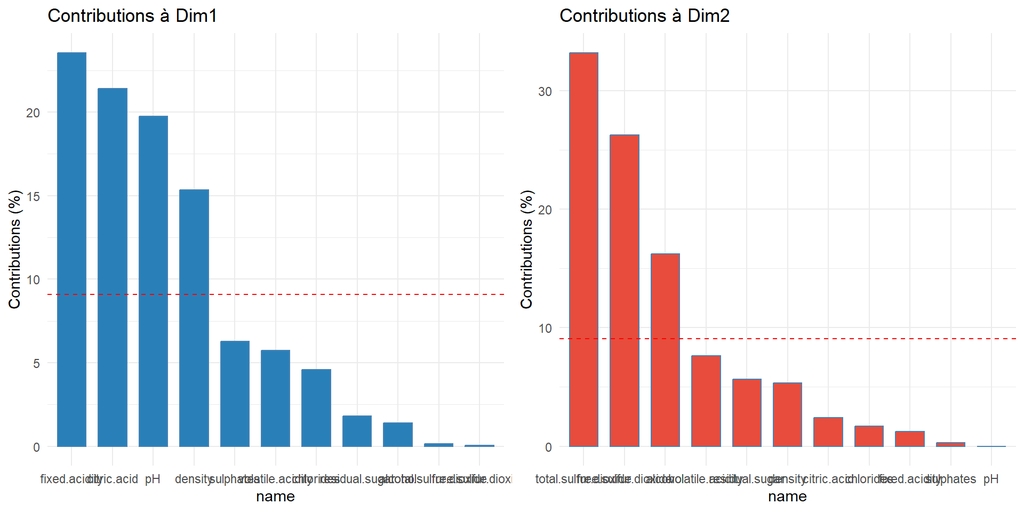

```r
p1 <- fviz_contrib(acp, choice = "var", axes = 1, fill = "#2980B9") +
  labs(title = "Contributions à Dim1") + theme_minimal()
p2 <- fviz_contrib(acp, choice = "var", axes = 2, fill = "#E74C3C") +
  labs(title = "Contributions à Dim2") + theme_minimal()
grid.arrange(p1, p2, ncol = 2)
```

## 5.4 Cercle des corrélations

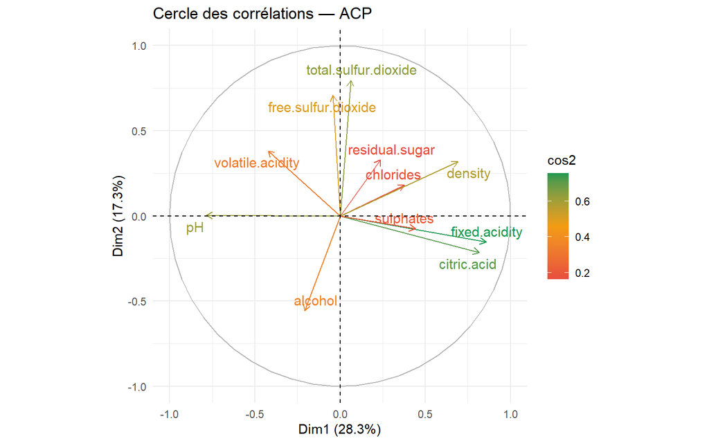

```r
fviz_pca_var(acp,
             col.var       = "cos2",
             gradient.cols = c("#E74C3C", "#F39C12", "#1A9850"),
             repel         = TRUE,
             title         = "Cercle des corrélations — ACP") +
  theme_minimal()
```

> - **Dim1 (28.3%) — Acidité & Structure :** `fixed.acidity`, `citric.acid`, `density`, `sulphates` (droite) vs `pH`, `volatile.acidity` (gauche).
> - **Dim2 (17.3%) — SO₂ & Alcool :** `free.sulfur.dioxide`, `total.sulfur.dioxide` (haut) vs `alcohol` (bas).

# 6 Classification

## 6.1 K-Means

### 6.1.1 Nombre optimal de clusters — Méthode Elbow

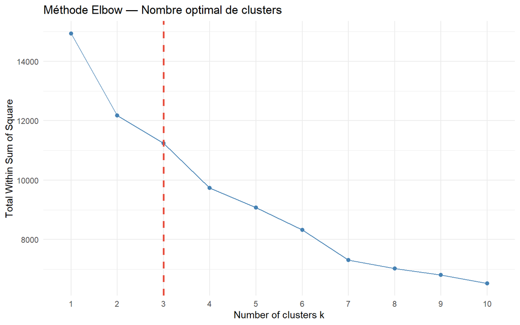

```r
fviz_nbclust(wine_scaled, kmeans, method = "wss", k.max = 10) +
  geom_vline(xintercept = 3, linetype = "dashed",
             color = "#E74C3C", linewidth = 1) +
  labs(title = "Méthode Elbow — Nombre optimal de clusters") +
  theme_minimal()
```

### 6.1.2 Nombre optimal — Méthode Silhouette

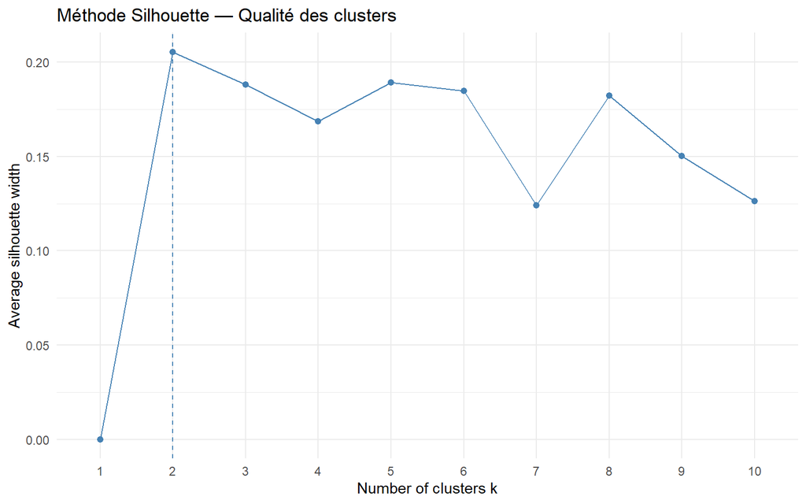

```r
fviz_nbclust(wine_scaled, kmeans, method = "silhouette", k.max = 10) +
  labs(title = "Méthode Silhouette — Qualité des clusters") +
  theme_minimal()
```

> **Décision :** `k = 3` retenu (coude Elbow + richesse interprétative).

### 6.1.3 Application du K-Means (k = 3)

```r
set.seed(123)
km <- kmeans(wine_scaled, centers = 3, nstart = 25)

cat("=== Taille des clusters ===\n")
```

```
## === Taille des clusters ===
```

```r
print(table(km$cluster))
```

```
##
##   1   2   3
## 431 610 318
```

```r
cat("Part expliquée :", round(km$betweenss / km$totss * 100, 1), "%\n")
```

[output not shown]

### 6.1.4 Visualisation des clusters

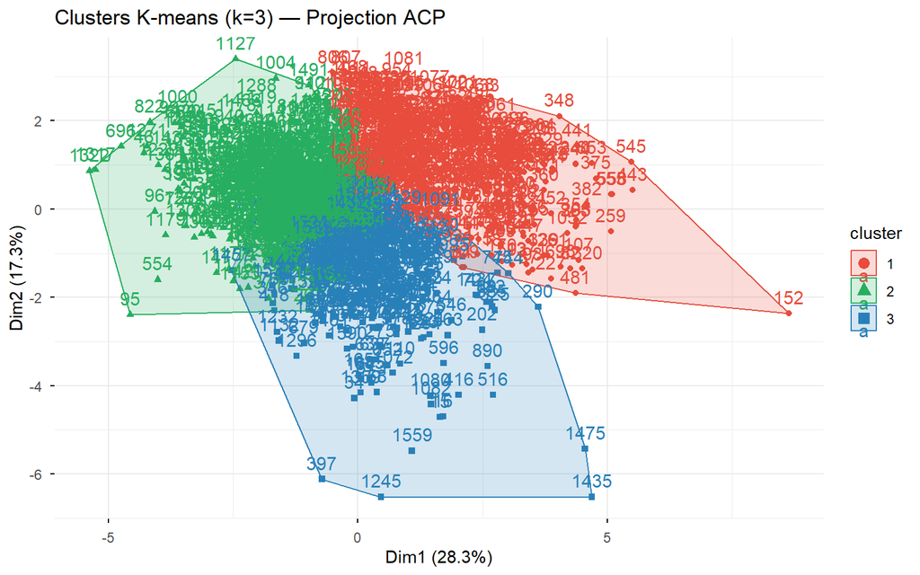

```r
fviz_cluster(km,
             data         = wine_scaled,
             palette      = c("#E74C3C", "#27AE60", "#2980B9"),
             ellipse.type = "convex",
             ggtheme      = theme_minimal(),
             main         = "Clusters K-means (k=3) — Projection ACP")
```

### 6.1.5 Profils moyens des clusters

```r
wine_clean$cluster <- as.factor(km$cluster)

profils <- wine_clean %>%
  group_by(cluster) %>%
  summarise(across(1:11, mean), quality = mean(quality), n = n())

print(round(profils[, -1], 2))
```

```
## # A tibble: 3 × 13
##   fixed.acidity volatile.acidity citric.acid residual.sugar chlorides
##           <dbl>            <dbl>       <dbl>          <dbl>     <dbl>
## 1         10.0              0.41        0.47           2.57      0.1
## 2          7.17             0.61        0.12           2.23      0.08
## 3          8.17             0.53        0.29           3.01      0.09
## # ℹ 8 more variables: free.sulfur.dioxide <dbl>, total.sulfur.dioxide <dbl>,
## #   density <dbl>, pH <dbl>, sulphates <dbl>, alcohol <dbl>, quality <dbl>,
## #   n <dbl>
```

> - **Cluster 1** : Acide & Structuré — qualité moyenne ≈ 5.97
> - **Cluster 2** : Léger & Défectueux — qualité moyenne ≈ 5.54
> - **Cluster 3** : Alcoolisé & Soufré — qualité moyenne ≈ 5.32

## 6.2 Classification Ascendante Hiérarchique (CAH)

### 6.2.1 Échantillonnage et matrice de distances

```r
set.seed(123)
idx         <- sample(1:nrow(wine_scaled), 150)
wine_sample <- wine_scaled[idx, ]

dist_matrix <- dist(wine_sample, method = "euclidean")
```

### 6.2.2 CAH — Méthode Ward

```r
cah <- hclust(dist_matrix, method = "ward.D2")
```

### 6.2.3 Dendrogramme

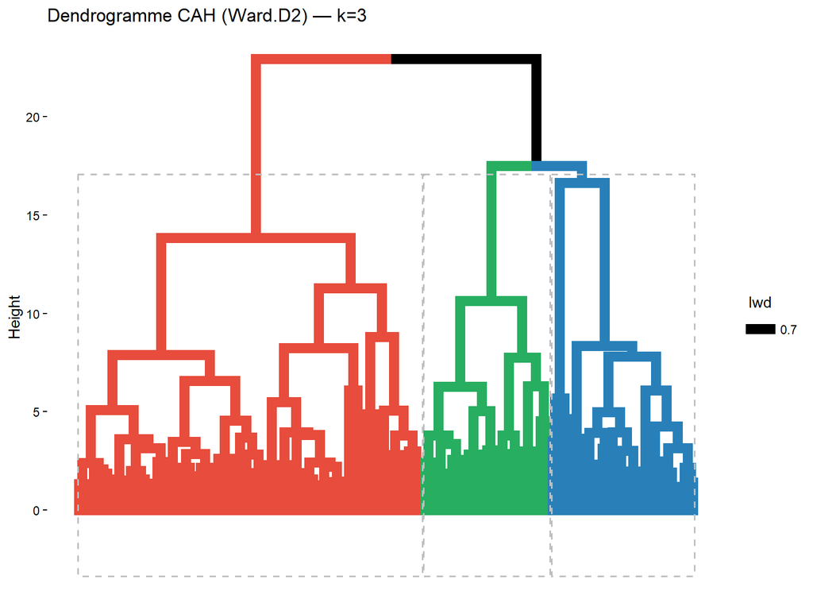

```r
fviz_dend(cah,
          k           = 3,
          palette     = c("#E74C3C", "#27AE60", "#2980B9"),
          rect        = TRUE,
          show_labels = FALSE,
          main        = "Dendrogramme CAH (Ward.D2) — k=3")
```

### 6.2.4 Répartition des groupes CAH

```r
groupes_cah <- cutree(cah, k = 3)
cat("=== Répartition CAH ===\n")
```

```
## === Répartition CAH ===
```

```r
print(table(groupes_cah))
```

```
## groupes_cah
##  1  2  3
## 31 35 84
```

# 7 Analyse combinée ACP + Clustering

## 7.1 Projection des clusters sur le plan ACP

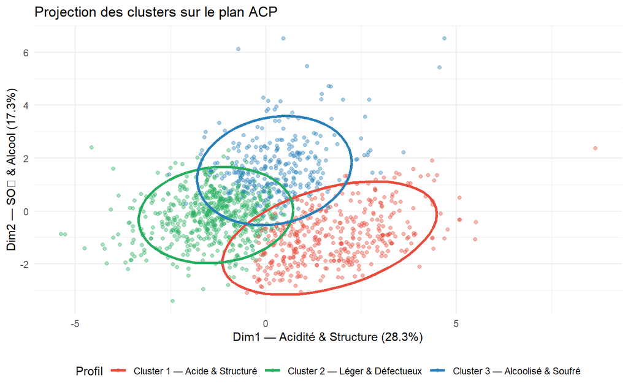

```r
coords_acp           <- as.data.frame(acp$ind$coord[, 1:2])
coords_acp$cluster   <- as.factor(km$cluster)
coords_acp$quality   <- wine_quality

ggplot(coords_acp, aes(x = Dim.1, y = Dim.2, color = cluster)) +
  geom_point(alpha = 0.4, size = 1.5) +
  stat_ellipse(level = 0.95, linewidth = 1.2) +
  scale_color_manual(
    values = c("#E74C3C", "#27AE60", "#2980B9"),
    labels = c("Cluster 1 — Acide & Structuré",
               "Cluster 2 — Léger & Défectueux",
               "Cluster 3 — Alcoolisé & Soufré")
  ) +
  labs(title  = "Projection des clusters sur le plan ACP",
       x      = "Dim1 — Acidité & Structure (28.3%)",
       y      = "Dim2 — SO₂ & Alcool (17.3%)",
       color  = "Profil") +
  theme_minimal() +
  theme(legend.position = "bottom")
```

## 7.2 Distribution de la qualité par cluster

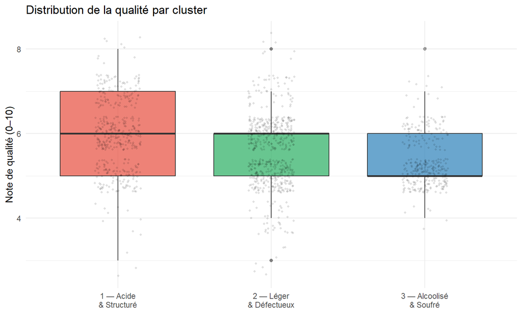

```r
ggplot(coords_acp, aes(x = cluster, y = quality, fill = cluster)) +
  geom_boxplot(alpha = 0.7, outlier.colour = "gray50") +
  geom_jitter(width = 0.15, alpha = 0.1, size = 0.8) +
  scale_fill_manual(values = c("#E74C3C", "#27AE60", "#2980B9")) +
  scale_x_discrete(labels = c("1 — Acide\n& Structuré",
                               "2 — Léger\n& Défectueux",
                               "3 — Alcoolisé\n& Soufré")) +
  labs(title = "Distribution de la qualité par cluster",
       x = "", y = "Note de qualité (0–10)") +
  theme_minimal() +
  theme(legend.position = "none")
```

## 7.3 Tableau récapitulatif

```r
resume_qualite <- coords_acp %>%
  group_by(cluster) %>%
  summarise(
    qualite_moyenne = round(mean(quality), 2),
    ecart_type      = round(sd(quality), 2),
    n               = n()
  )
print(resume_qualite)
```

```
## # A tibble: 3 × 4
##   cluster qualite_moyenne ecart_type     n
##   <fct>             <dbl>      <dbl> <int>
## 1 1                  5.97       0.86   431
## 2 2                  5.54       0.82   610
## 3 3                  5.32       0.58   318
```

# 8 Conclusion

[output not shown]